# Correlation Analysis

## Load packages

```r
library(tidyverse)
library(readxl)
library(ggpubr)
library(broom)
```

## Load data

```r
# Rt data
o_rt <- read_csv('Estimated_R/ontario_R.csv')
p_rt <- read_csv('Estimated_R/peel_R.csv')
t_rt <- read_csv('Estimated_R/tor_R.csv')
w_rt <- read_csv('Estimated_R/wat_R.csv')
y_rt <- read_csv('Estimated_R/york_R.csv')
# Mobility data
mob <- read_csv('2020_CA_Region_Mobility_Report.csv')
mob <- mob %>%
  mutate(`Global Mobility Score` = (retail_and_recreation_percent_change_from_baseline + grocery_and_pharmacy_percent_change_from_baseline + parks_percent_change_from_baseline + transit_stations_percent_change_from_baseline + workplaces_percent_change_from_baseline + residential_percent_change_from_baseline)/6)
o_mob <- mob %>%
  filter(sub_region_1=='Ontario' & is.na(sub_region_2))
p_mob <- mob %>%
  filter(sub_region_1=='Ontario' & sub_region_2=='Regional Municipality of Peel')
t_mob <- mob %>%
  filter(sub_region_1=='Ontario' & sub_region_2=='Toronto Division')
w_mob <- mob %>%
  filter(sub_region_1=='Ontario' & sub_region_2=='Waterloo Regional Municipality')
y_mob <- mob %>%
  filter(sub_region_1=='Ontario' & sub_region_2=='Regional Municipality of York')
```

## Lockdown timeline

### Second wave

(Gray)  
Ontario: 12/26/20 - 1/22/21 Peel: 11/23/20 - 1/22/21  
Toronto: 11/23/20 - 1/22/21 Waterloo: 12/26/20 - 1/22/21  
York: 12/14/20 - 1/22/21

```r
# # take log of R to prevent negative predictions
# mutate(`ln(R)` = log(`Mean(R)`)) %>%
```

## Function to convert data into useful form

Input: mobility data, rt data, lockdown start date, lockdown end date, columns to keep  
Output: Df of specific region to run regressions on

```r
get_data <- function(mob_data, rt_data, lock_start, lock_end, cols) {
  df <- mob_data %>%
    left_join(rt_data, by=c("date" = "date_start")) %>%
    select(all_of(cols)) %>%
    mutate(date = as.Date(date)) %>%
    rename(retail=retail_and_recreation_percent_change_from_baseline,grocery=grocery_and_pharmacy_percent_change_from_baseline, parks=parks_percent_change_from_baseline, transit=transit_stations_percent_change_from_baseline, workplaces=workplaces_percent_change_from_baseline, residential=residential_percent_change_from_baseline, global=`Global Mobility Score`) %>%
    mutate(retail_lag7 = lag(retail, 7)) %>%
    mutate(grocery_lag7 = lag(grocery, 7) ) %>%
    mutate(parks_lag7 = lag(parks, 7)) %>%
    mutate(transit_lag7 = lag(transit, 7)) %>%
    mutate(workplaces_lag7 = lag(workplaces, 7)) %>%
    mutate(residential_lag7 = lag(residential, 7)) %>%
    mutate(global_lag7 = lag(global, 7)) %>%
    mutate(retail_lag14 = lag(retail, 14)) %>%
    mutate(grocery_lag14 = lag(grocery, 14) ) %>%
    mutate(parks_lag14 = lag(parks, 14)) %>%
    mutate(transit_lag14 = lag(transit, 14)) %>%
    mutate(workplaces_lag14 = lag(workplaces, 14)) %>%
    mutate(residential_lag14 = lag(residential, 14)) %>%
    mutate(global_lag14 = lag(global, 14)) %>%
    filter(date>=lock_start & date<=lock_end)
  return(df)
}
```

## Function to get correlation data

Input: Df of specific region, desired mobility lag time (0, 7, or 14 days)  
Output: Df of specific region with list of correlations for each mobility

```r
get_correlations <- function(data, lag) {
  if(lag==0) {
    retail <- cor.test(data$`Mean(R)`, data$retail, method = 'pearson')
    grocery <- cor.test(data$`Mean(R)`, data$grocery, method = 'pearson')
    parks <- cor.test(data$`Mean(R)`, data$parks, method = 'pearson')
    transit <- cor.test(data$`Mean(R)`, data$transit, method = 'pearson')
    workplaces <- cor.test(data$`Mean(R)`, data$workplaces, method = 'pearson')
    residential <- cor.test(data$`Mean(R)`, data$residential, method = 'pearson')
    global <- cor.test(data$`Mean(R)`, data$global, method = 'pearson')
  } else if(lag==7) {
    retail <- cor.test(data$`Mean(R)`, data$retail_lag7, method = 'pearson')
    grocery <- cor.test(data$`Mean(R)`, data$grocery_lag7, method = 'pearson')
    parks <- cor.test(data$`Mean(R)`, data$parks_lag7, method = 'pearson')
    transit <- cor.test(data$`Mean(R)`, data$transit_lag7, method = 'pearson')
    workplaces <- cor.test(data$`Mean(R)`, data$workplaces_lag7, method = 'pearson')
    residential <- cor.test(data$`Mean(R)`, data$residential_lag7, method = 'pearson')
    global <- cor.test(data$`Mean(R)`, data$global_lag7, method = 'pearson')
  } else if(lag==14) {
    retail <- cor.test(data$`Mean(R)`, data$retail_lag14, method = 'pearson')
    grocery <- cor.test(data$`Mean(R)`, data$grocery_lag14, method = 'pearson')
    parks <- cor.test(data$`Mean(R)`, data$parks_lag14, method = 'pearson')
    transit <- cor.test(data$`Mean(R)`, data$transit_lag14, method = 'pearson')
    workplaces <- cor.test(data$`Mean(R)`, data$workplaces_lag14, method = 'pearson')
    residential <- cor.test(data$`Mean(R)`, data$residential_lag14, method = 'pearson')
    global <- cor.test(data$`Mean(R)`, data$global_lag14, method = 'pearson')
  } else {
    stop('Must enter 0, 7, or 14')
  }

  return(list(retail=retail, grocery=grocery, parks=parks, transit=transit, workplaces=workplaces, residential=residential, global=global))
}
```

## Function to get correlation coefficient

Input: List of region df’s each containing coefficient info  
Output: Coefficient data df of specified lag time

```r
corr_coef <- function(data) {
  place <- numeric(length=35)
  mobility <- numeric(length=35)
  coefficient <- numeric(length=35)
  p_val <- numeric(length=35)
  i=1
  j=1
  k=1
  for(loc in data){
    for(corr in loc) {
      place[i] <- names(data)[j]
      mobility[i] <- names(loc)[k]
      coefficient[i] <- corr$estimate[[1]]
      p_val[i] <- corr$p.value
      i=i+1
      k=k+1
    }
    j=j+1
    k=1
  }
  df <- data.frame(place, mobility, coefficient, p_val)
  return(df)
}
```

## Function to get regression data

Input: Df of specific region, desired mobility lag time (0, 7, or 14 days)  
Output: Df of specific region with list of regressions for each mobility

```r
get_regressions <- function(data, lag) {
  if(lag==0) {
    retail <- lm(`Mean(R)` ~ retail, data = data)
    grocery <- lm(`Mean(R)` ~ grocery, data = data)
    parks <- lm(`Mean(R)` ~ parks, data = data)
    transit <- lm(`Mean(R)` ~ transit, data = data)
    workplaces <- lm(`Mean(R)` ~ workplaces, data = data)
    residential <- lm(`Mean(R)` ~ residential, data = data)
    global <- lm(`Mean(R)` ~ global, data = data)
  } else if(lag==7) {
    retail <- lm(`Mean(R)` ~ retail_lag7, data = data)
    grocery <- lm(`Mean(R)` ~ grocery_lag7, data = data)
    parks <- lm(`Mean(R)` ~ parks_lag7, data = data)
    transit <- lm(`Mean(R)` ~ transit_lag7, data = data)
    workplaces <- lm(`Mean(R)` ~ workplaces_lag7, data = data)
    residential <- lm(`Mean(R)` ~ residential_lag7, data = data)
    global <- lm(`Mean(R)` ~ global_lag7, data = data)
  } else if(lag==14) {
    retail <- lm(`Mean(R)` ~ retail_lag14, data = data)
    grocery <- lm(`Mean(R)` ~ grocery_lag14, data = data)
    parks <- lm(`Mean(R)` ~ parks_lag14, data = data)
    transit <- lm(`Mean(R)` ~ transit_lag14, data = data)
    workplaces <- lm(`Mean(R)` ~ workplaces_lag14, data = data)
    residential <- lm(`Mean(R)` ~ residential_lag14, data = data)
    global <- lm(`Mean(R)` ~ global_lag14, data = data)
  } else {
    stop('Must enter 0, 7, or 14')
  }
  return(list(retail=retail, grocery=grocery, parks=parks, transit=transit, workplaces=workplaces, residential=residential, global=global))
}
```

## Function to get regression coefficient

Input: List of region df’s each containing regression info  
Output: Coefficient data df of specified lag time

```r
reg_coef <- function(data) {
  place <- numeric(length=35)
  mobility <- numeric(length=35)
  coefficient <- numeric(length=35)
  r2 <- numeric(length=35)
  p_val <- numeric(length=35)
  i=1
  j=1
  k=1
  for(loc in data){
    for(reg in loc) {
      place[i] <- names(data)[j]
      mobility[i] <- names(loc)[k]
      coefficient[i] <- tidy(reg)[[2,2]]
      r2[i] <- glance(reg)[[1,2]]
      p_val[i] <- glance(reg)[[1,5]]
      i=i+1
      k=k+1
    }
    j=j+1
    k=1
  }
  df <- data.frame(place, mobility, coefficient, r2, p_val)
  return(df)
}
```

## Pipeline

Columns to keep

```r
COLS <- c('sub_region_1', 'date', 'retail_and_recreation_percent_change_from_baseline','grocery_and_pharmacy_percent_change_from_baseline', 'parks_percent_change_from_baseline', 'transit_stations_percent_change_from_baseline', 'workplaces_percent_change_from_baseline', 'residential_percent_change_from_baseline', 'Global Mobility Score', 'Mean(R)')
```

Get data

```r
# Wave 1
o <- get_data(o_mob, o_rt, '2020-03-17', '2020-05-20', COLS)
p <- get_data(p_mob, p_rt, '2020-03-17', '2020-06-22', COLS)
t <- get_data(t_mob, t_rt, '2020-03-17', '2020-06-24', COLS)
w <- get_data(w_mob, w_rt, '2020-03-17', '2020-06-12', COLS)
y <- get_data(y_mob, y_rt, '2020-03-17', '2020-05-19', COLS)

# Wave 2
o2 <- get_data(o_mob, o_rt, '2020-12-26', '2021-01-22', COLS)
p2 <- get_data(p_mob, p_rt, '2020-11-23', '2021-01-22', COLS)
t2 <- get_data(t_mob, t_rt, '2020-11-23', '2021-01-22', COLS)
w2 <- get_data(w_mob, w_rt, '2020-12-26', '2021-01-22', COLS)
y2 <- get_data(y_mob, y_rt, '2020-12-14', '2021-01-22', COLS)
```

0 day lag

```r
# Wave 1
zero_corr <- list(
  ontario=get_correlations(o, 0),
  peel=get_correlations(p, 0),
  toronto=get_correlations(t, 0),
  waterloo=get_correlations(w, 0),
  york=get_correlations(y, 0)
)
zero_reg <- list(
  ontario=get_regressions(o, 0),
  peel=get_regressions(p, 0),
  toronto=get_regressions(t, 0),
  waterloo=get_regressions(w, 0),
  york=get_regressions(y, 0)
)

# Wave 2
zero_corr2 <- list(
  ontario=get_correlations(o2, 0),
  peel=get_correlations(p2, 0),
  toronto=get_correlations(t2, 0),
  waterloo=get_correlations(w2, 0),
  york=get_correlations(y2, 0)
)
zero_reg2 <- list(
  ontario=get_regressions(o2, 0),
  peel=get_regressions(p2, 0),
  toronto=get_regressions(t2, 0),
  waterloo=get_regressions(w2, 0),
  york=get_regressions(y2, 0)
)
```

7 day lag

```r
# Wave 1
seven_corr <- list(
  ontario=get_correlations(o, 7),
  peel=get_correlations(p, 7),
  toronto=get_correlations(t, 7),
  waterloo=get_correlations(w, 7),
  york=get_correlations(y, 7)
)
seven_reg <- list(
  ontario=get_regressions(o, 7),
  peel=get_regressions(p, 7),
  toronto=get_regressions(t, 7),
  waterloo=get_regressions(w, 7),
  york=get_regressions(y, 7)
)

# Wave 2
seven_corr2 <- list(
  ontario=get_correlations(o2, 7),
  peel=get_correlations(p2, 7),
  toronto=get_correlations(t2, 7),
  waterloo=get_correlations(w2, 7),
  york=get_correlations(y2, 7)
)
seven_reg2 <- list(
  ontario=get_regressions(o2, 7),
  peel=get_regressions(p2, 7),
  toronto=get_regressions(t2, 7),
  waterloo=get_regressions(w2, 7),
  york=get_regressions(y2, 7)
)
```

14 day lag

```r
fourteen_corr <- list(
  ontario = get_correlations(o, 14),
  peel = get_correlations(p, 14),
  toronto = get_correlations(t, 14),
  waterloo = get_correlations(w, 14),
  york = get_correlations(y, 14)
)
fourteen_reg <- list(
  ontario = get_regressions(o, 14),
  peel = get_regressions(p, 14),
  toronto = get_regressions(t, 14),
  waterloo = get_regressions(w, 14),
  york = get_regressions(y, 14)
)
fourteen_corr2 <- list(
  ontario = get_correlations(o2, 14),
  peel = get_correlations(p2, 14),
  toronto = get_correlations(t2, 14),
  waterloo = get_correlations(w2, 14),
  york = get_correlations(y2, 14)
)
fourteen_reg2 <- list(
  ontario = get_regressions(o2, 14),
  peel = get_regressions(p2, 14),
  toronto = get_regressions(t2, 14),
  waterloo = get_regressions(w2, 14),
  york = get_regressions(y2, 14)
)
```

Get coefficient data for each time lag Add period column, later factor it appropriately Combine into one df (total) Check if each p-value is statistically significant (<0.01)

```r
# Wave 1
zero_corr_coef <- corr_coef(zero_corr)
zero_corr_coef$period <- rep('Lockdown', times=35)

seven_corr_coef <- corr_coef(seven_corr)
seven_corr_coef$period <- rep('7 Days after lockdown', times=35)

fourteen_corr_coef <- corr_coef(fourteen_corr)
fourteen_corr_coef$period <- rep('14 Days after lockdown', times=35)

total_corr <- rbind(zero_corr_coef, seven_corr_coef, fourteen_corr_coef)
total_corr$wave <- rep('Wave 1', times=105)

# Wave 2
zero_corr_coef2 <- corr_coef(zero_corr2)
zero_corr_coef2$period <- rep('Lockdown', times=35)

seven_corr_coef2 <- corr_coef(seven_corr2)
seven_corr_coef2$period <- rep('7 Days after lockdown', times=35)

fourteen_corr_coef2 <- corr_coef(fourteen_corr2)
fourteen_corr_coef2$period <- rep('14 Days after lockdown', times=35)

total_corr2 <- rbind(zero_corr_coef2, seven_corr_coef2, fourteen_corr_coef2)
total_corr2$wave <- rep('Wave 2', times=105)

# Combine
total_correlation <- rbind(total_corr, total_corr2)

total_correlation$period <- factor(total_correlation$period, levels=c('Lockdown', '7 Days after lockdown', '14 Days after lockdown'))
total_correlation <- total_correlation %>%
  mutate(
    significant = case_when(
      p_val < 0.01 ~ 'Yes',
      p_val >= 0.01 ~ 'No'
    )
  )

write_csv(total_correlation, 'Correlation_Analysis/corr_coef.csv')
```

Get coefficient data for each time lag Add period column, later factor it appropriately Combine into one df (total) Check if each p-value is statistically significant (<0.01)

```r
# Wave 1
zero_reg_coef <- reg_coef(zero_reg)
zero_reg_coef$period <- rep('Lockdown', times=35)

seven_reg_coef <- reg_coef(seven_reg)
seven_reg_coef$period <- rep('7 Days after lockdown', times=35)

fourteen_reg_coef <- reg_coef(fourteen_reg)
fourteen_reg_coef$period <- rep('14 Days after lockdown', times=35)

total_reg <- rbind(zero_reg_coef, seven_reg_coef, fourteen_reg_coef)
total_reg$wave <- rep('Wave 1', times=105)

# Wave 2
zero_reg_coef2 <- reg_coef(zero_reg2)
zero_reg_coef2$period <- rep('Lockdown', times=35)

seven_reg_coef2 <- reg_coef(seven_reg2)
seven_reg_coef2$period <- rep('7 Days after lockdown', times=35)

fourteen_reg_coef2 <- reg_coef(fourteen_reg2)
fourteen_reg_coef2$period <- rep('14 Days after lockdown', times=35)

total_reg2 <- rbind(zero_reg_coef2, seven_reg_coef2, fourteen_reg_coef2)
total_reg2$wave <- rep('Wave 2', times=105)

# Combine
total_regression <- rbind(total_reg, total_reg2)

total_regression$period <- factor(total_regression$period, levels=c('Lockdown', '7 Days after lockdown', '14 Days after lockdown'))
total_regression <- total_regression %>%
  mutate(
    significant = case_when(
      p_val < 0.01 ~ 'Yes',
      p_val >= 0.01 ~ 'No'
    )
  )

write_csv(total_regression, 'Correlation_Analysis/reg_coef.csv')
```

## Barplot

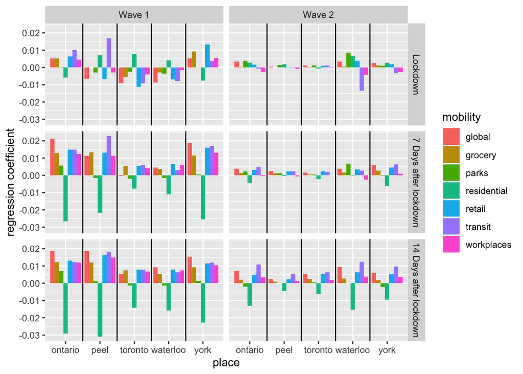

```r
p <- ggplot(total_regression, aes(x=place, y=coefficient, fill=mobility)) +
  geom_col(position = 'dodge') +
  geom_vline(xintercept = c(1.5, 2.5, 3.5, 4.5)) +
  facet_grid(rows=vars(period), cols=vars(wave)) +
  ylab('regression coefficient')
  # theme_bw()
ggsave('Correlation_analysis/reg_barplot.png',
       p,
       height = 8.5,
       width = 11,
       units = 'in')
p
```

Regression coefficients of each type of mobility with Rt as the dependent variable. A simple way to grasp regression coefficients is to picture them as linear slopes. There is a strong, positive association between almost each type of mobility score and Rt during the periods 7 days after lockdown and 14 days after lockdown. Most of the time, when mobility score is high, Rt is also high.The exception is residential mobility; there is a strong, negative association between residential mobility score and Rt during the periods 7 days after lockdown and 14 days after lockdown. When residential mobility score is high, Rt is low. This suggests that there is a lag time before changes in global mobility score are reflected in Rt values.

## Lineplot

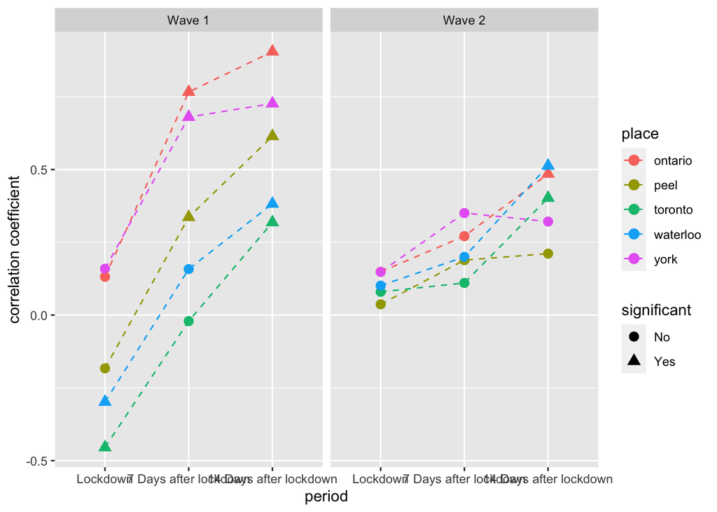

```r
d <- filter(total_correlation, mobility=='global')
p <- ggplot(d, aes(x=period, y=coefficient, group=place, color=place)) +
  geom_point(d, mapping=aes(shape=significant), size=3) +
  geom_line(linetype='dashed') +
  facet_grid(cols=vars(wave)) +
  ylab('correlation coefficient')
  # theme_bw()
ggsave('Correlation_analysis/corr_lineplot.png',
       p,
       height = 8.5,
       width = 11,
       units = 'in')
p
```

Correlation coefficient formulas are used to find how strong a relationship is between data. The formulas return a value between -1 and 1, where:

1 indicates a strong positive relationship. -1 indicates a strong negative relationship. A result of zero indicates no relationship at all.

```r
ont <- ggplot(o, aes(x=global_lag14, y=`Mean(R)`)) +
  geom_point() +
  geom_smooth(method='lm') +
  labs(title = 'ontario 14 days after lockdown') +
  annotate("text", x = 0, y = 1, label = "Pearson's coef=0.904\nMean(R)=0.019(global_lag14)+1.607")
tor <- ggplot(t, aes(x=global, y=`Mean(R)`)) +
  geom_point() +
  geom_smooth(method='lm') +
  labs(title='toronto after lockdown') +
  annotate("text", x = -8, y = 1.5, label = "Pearson's coef=-0.455\nMean(R)=-0.009(global) + 0.835")
ggsave('Correlation_analysis/examples/ontario14.png',
       ont)
ggsave('Correlation_analysis/examples/toronto0.png',
       tor)
```